# **40 Books Donation List**

Modified

September 3, 2026

## About This List

**📚 How to Donate a Book to SARA**

SARA Institute of Data Science is building a **Bridge Course: Level 1** for first-generation learners and students from marginalised communities. You can support us by donating a book from this list in two ways:

- **Send your old copy** - Post your pre-loved book directly to us at the address below
- **Buy & ship new** - Purchase a new copy online and have it delivered to SARA

**📬 Delivery address:** SARA Institute, Dr. Ambedkar Bhawan, Kakroi Road, Sonipat Haryana - 131001, Mobile No. +91 925 315 2024

**✉️ Notify us after sending:** sara.institute.info@gmail.com

*Please email us with your name and the book title so we can acknowledge your donation and update this list.*

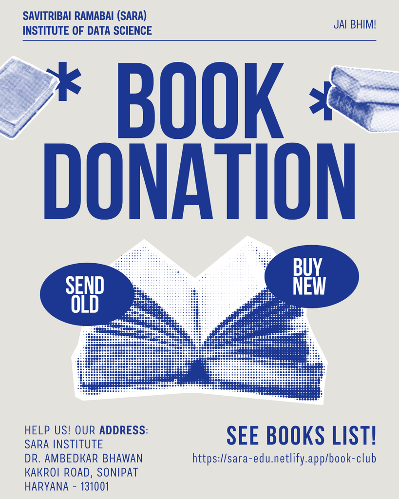

## Book Donation Tracker

Use the **search box** to find a specific book, or **filter by subject or status** using the column filters below.

**🟢 Status Guide**

- 🟢 **Received** - We have this book. Thank you to our donors!
- 🟡 **In Transit** - A donor has sent this and it is on its way
- 🔴 **Needed** - This book still needs a donor

### SARA Library Progress

**Note**

**📦 Total Books**

# 40

on the wishlist

**Tip**

**🟢 Received**

# 25

already on the shelf

**Warning**

**🟡 In Transit**

# 1

on the way to us

**Important**

**🔴 Still Needed**

# 14

waiting for a donor

**62% of our library goal reached.** Every book brings us closer.

### Full Book List

[figure not shown]

## By Subject

[figure not shown]

## How to Notify Us

After sending a book, please email us at **sara.institute.info@gmail.com** with:

1. Your **name** (for acknowledgement)
2. The **book title** you are donating
3. Whether you sent an **old copy** or purchased a **new one**
4. Your **city / country** (so we can thank our community publicly if you wish)

We update this list regularly. Thank you for supporting free, dignified education.

**Note**

*This list is maintained by SARA Institute of Data Science, Sonipat. Last updated: 03 September 2026*

Back to top